# IODS course project

Konrad Sopyllo

# Introduction to Open Data Science - Course Project

# About the project

*Write a short description about the course and add a link to your GitHub repository here. This is an R Markdown (.Rmd) file so you should use R Markdown syntax.*

To be fair I’m not a huge fan of statistics and computer sciences. I’m working as a doctor and doing my PhD on the side. I did one of such courses more than two years ago and i have forgotten most of it by now. There aren’t many courses available to be done fully remotely. Thus I’m happy to have found this one on Sisu. I hope to refresh what I have already done in the past and to learn some new skills that will enable me to analyze data for my research.

The exercise set was a good way to start getting familiar with the course content and checking weather everything is working as it should. The most difficult part for me is organizing big sets of data with different variables as in last section of the exercise. The book gives a good insight to the basic commands in Rstudio. Nowadays it is also very easy to find support simply by googling the issue. So far I liked the instructions on the Moodle platform. Everything seem to be working fine so far. Looking forward to the real tasks.

https://github.com/konradsopyllo/IODS-project.git

```r
# This is a so-called "R chunk" where you can write R code.

date()
```

```
## [1] "Wed Nov 22 10:24:59 2023"
```

# Assignment 2

- Describe your work and results clearly.
- Assume the reader has an introductory course level understanding of writing and reading R code as well as statistical methods.
- Assume the reader has no previous knowledge of your data or the more advanced methods you are using.

#Konrad Sopyllo

The data presented below is based on a survey and the data was collected 3.12.2014 - 10.1.2015 in Florence,Italy. The data was translated in Finnish by Kimmo Vehkalahti and Liisa Myyry. The survey was based originally on a finnish study concerning the progress and satisfaction related to the double phased study programme in technical universities.

#Data wrangling

#In this data wrangling part we will focus brielfy on creating the data set as in the csv-file in the data-folder.

```r
library(tidyverse)
url<-"http://www.helsinki.fi/~kvehkala/JYTmooc/JYTOPKYS3-data.txt"
data=read_tsv(url)
```

#Creating an analysis_dataset with the variables gender, age, attitude, deep, stra, surf and points by combining the values in the learning2014 data. Note that Stra, surf and deep consist of multiple variables.

```r
collumns <- c("gender", "Age", "Attitude", "Points")

analysis_dataset <- data[collumns]
```

Other variables explained:

d_sm Seeking Meaning  
d_ri Relating Ideas  
d_ue Use of Evidence  
su_lp Lack of Purpose  
su_um Unrelated Memorising  
su_sb Syllabus-boundness  
st_os Organized Studying  
st_tm Time Management  
Deep Deep approach  
Surf Surface approach  
Stra Strategic approach

#Stra = st_os+st_tm = ST01+ST09+ST17+ST25+ST04+ST12+ST20+ST28

```r
stra_collumns = unlist(str_split(c("ST01+ST09+ST17+ST25+ST04+ST12+ST20+ST28"), "\\+"))
```

#surf = su_lp+su_um+su_sb = SU02+SU10+SU18+SU26 + SU05+SU13+SU21+SU29 + SU08+SU16+SU24+SU32

```r
surf_collumns = unlist(str_split(c("SU02+SU10+SU18+SU26+SU05+SU13+SU21+SU29+SU08+SU16+SU24+SU32"), "\\+"))
```

#deep = d_sm+d_ri+d_ue = D03+D11+D19+D27 + D07+D14+D22+D30 + D06+D15+D23+D31

```r
deep_collumns = unlist(str_split(c("D03+D11+D19+D27+D07+D14+D22+D30+D06+D15+D23+D31"), "\\+"))
```

# Adding stra, deep and surf by creating scaled variables using rowMeans-function.

```r
analysis_dataset["stra"] = rowMeans(select(data, one_of(stra_collumns)))
analysis_dataset["deep"] = rowMeans(select(data, one_of(deep_collumns)))
analysis_dataset["surf"] = rowMeans(select(data, one_of(surf_collumns)))
```

# filtering out rows where Points variable = 0

```r
analysis_dataset = analysis_dataset[analysis_dataset$Points != 0,]
dim(analysis_dataset)
```

```
## [1] 166   7
```

#As in the exercise provided the file has 166 observations and 7 variables

#Saving the analysis_dataset as a csv-file

```r
library(readr)
write_csv(analysis_dataset, "data/learning2014.csv")
```

#Showing how to read the csv-file

```r
loaded_data <- read_csv("data/learning2014.csv")
str(loaded_data)
```

```
## spc_tbl_ [166 × 7] (S3: spec_tbl_df/tbl_df/tbl/data.frame)
##  $ gender  : chr [1:166] "F" "M" "F" "M" ...
##  $ Age     : num [1:166] 53 55 49 53 49 38 50 37 37 42 ...
##  $ Attitude: num [1:166] 37 31 25 35 37 38 35 29 38 21 ...
##  $ Points  : num [1:166] 25 12 24 10 22 21 21 31 24 26 ...
##  $ stra    : num [1:166] 3.38 2.75 3.62 3.12 3.62 ...
##  $ deep    : num [1:166] 3.58 2.92 3.5 3.5 3.67 ...
##  $ surf    : num [1:166] 2.58 3.17 2.25 2.25 2.83 ...
##  - attr(*, "spec")=
##   .. cols(
##   ..   gender = col_character(),
##   ..   Age = col_double(),
##   ..   Attitude = col_double(),
##   ..   Points = col_double(),
##   ..   stra = col_double(),
##   ..   deep = col_double(),
##   ..   surf = col_double()
##   .. )
##  - attr(*, "problems")=<externalptr>
```

```r
head(loaded_data)
```

```
## # A tibble: 6 × 7
##   gender   Age Attitude Points  stra  deep  surf
##   <chr>  <dbl>    <dbl>  <dbl> <dbl> <dbl> <dbl>
## 1 F         53       37     25  3.38  3.58  2.58
## 2 M         55       31     12  2.75  2.92  3.17
## 3 F         49       25     24  3.62  3.5   2.25
## 4 M         53       35     10  3.12  3.5   2.25
## 5 M         49       37     22  3.62  3.67  2.83
## 6 F         38       38     21  3.62  4.75  2.42
```

###Data analysis

In this section we will focus further on analysing the data itself. The brief description of the contents of the data have been presented in the beginning of the file.

#Creating the correlation matrix

```r
library("Hmisc")
```

```r
library("corrplot")
library(ggplot2)
```

#Gender correlation

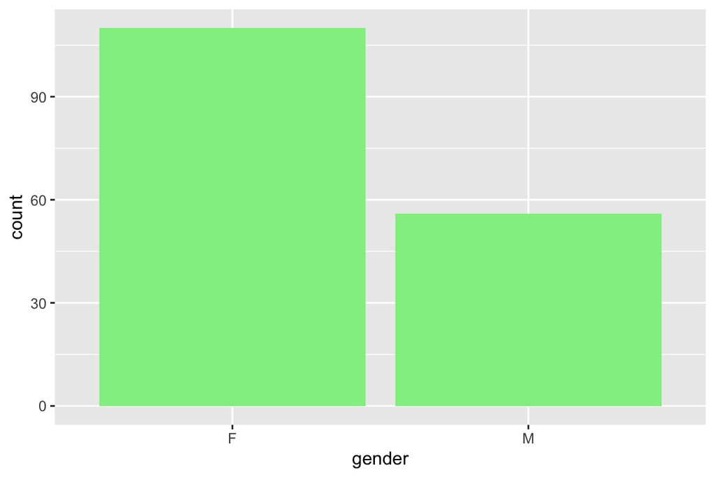

```r
gender_graph <- ggplot(data.frame(analysis_dataset), aes(x = gender)) +
  geom_bar(fill = "lightgreen")
print(gender_graph)
```

#Points correlation

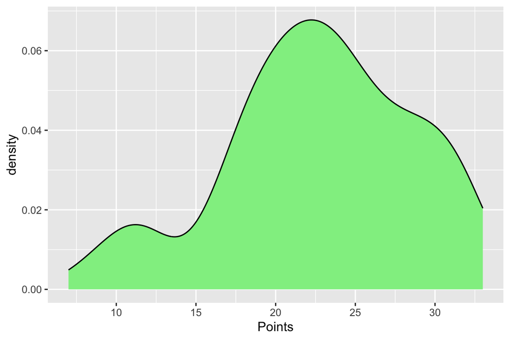

```r
points_dist <- ggplot(data.frame(analysis_dataset), aes(x =Points)) +
  geom_density(fill = "lightgreen")
print(points_dist)
```

#Age correlation

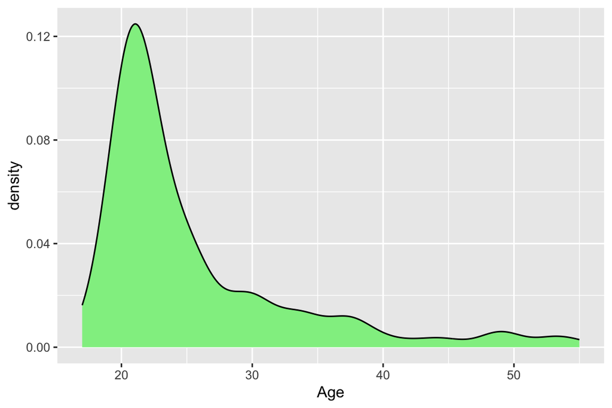

```r
age_dist <- points_dist <- ggplot(data.frame(analysis_dataset), aes(x = Age)) +
  geom_density(fill = "lightgreen")
print(points_dist)
```

#deep correlation

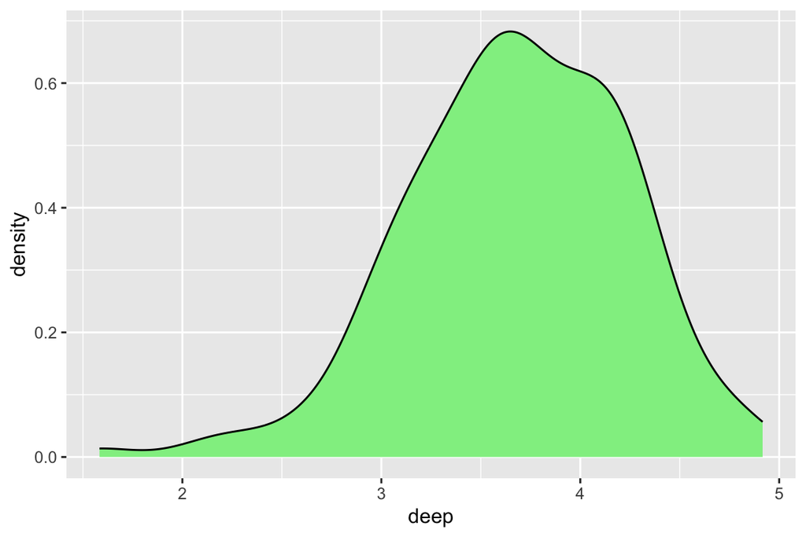

```r
deep_dist <- ggplot(data.frame(analysis_dataset), aes(x = deep)) +
  geom_density(fill = "lightgreen")
print(deep_dist)
```

#surf correlation

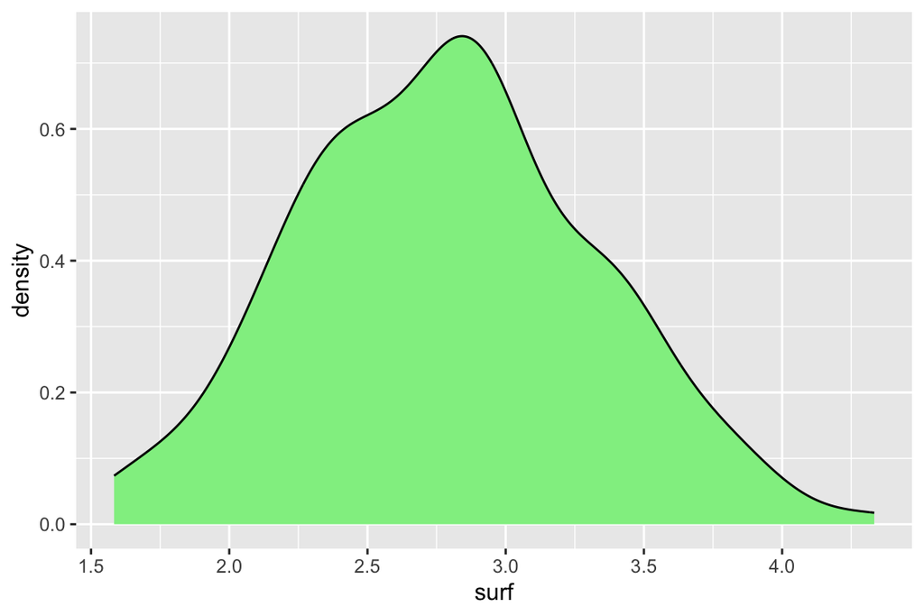

```r
surf_dist <- ggplot(data.frame(analysis_dataset), aes(x = surf)) +
  geom_density(fill = "lightgreen")
print(surf_dist)
```

#stra correlation

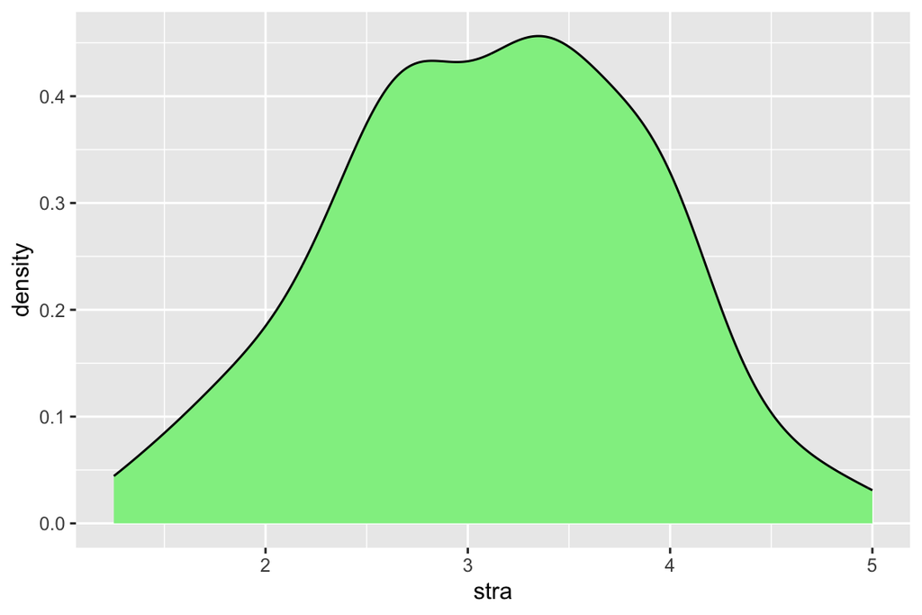

```r
stra_dist <- ggplot(data.frame(analysis_dataset), aes(x = stra)) +
  geom_density(fill = "lightgreen")
print(stra_dist)
```

#Creating a correlation graph of variables:“Attitude”,“deep”,“stra”,“surf”,“Points” using Pearson

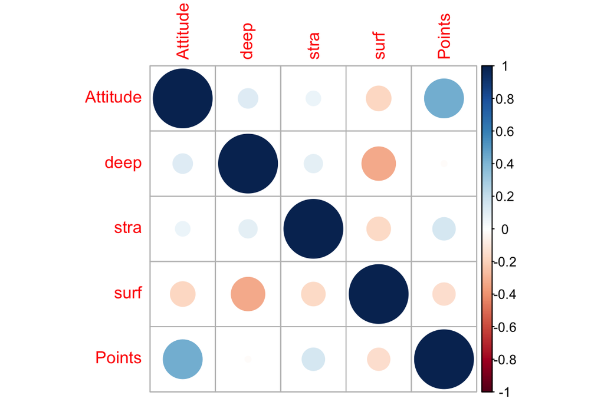

```r
correlations = c("Attitude","deep","stra","surf","Points")
analysis_cor = cor(analysis_dataset[correlations])
corrplot(analysis_cor)
```

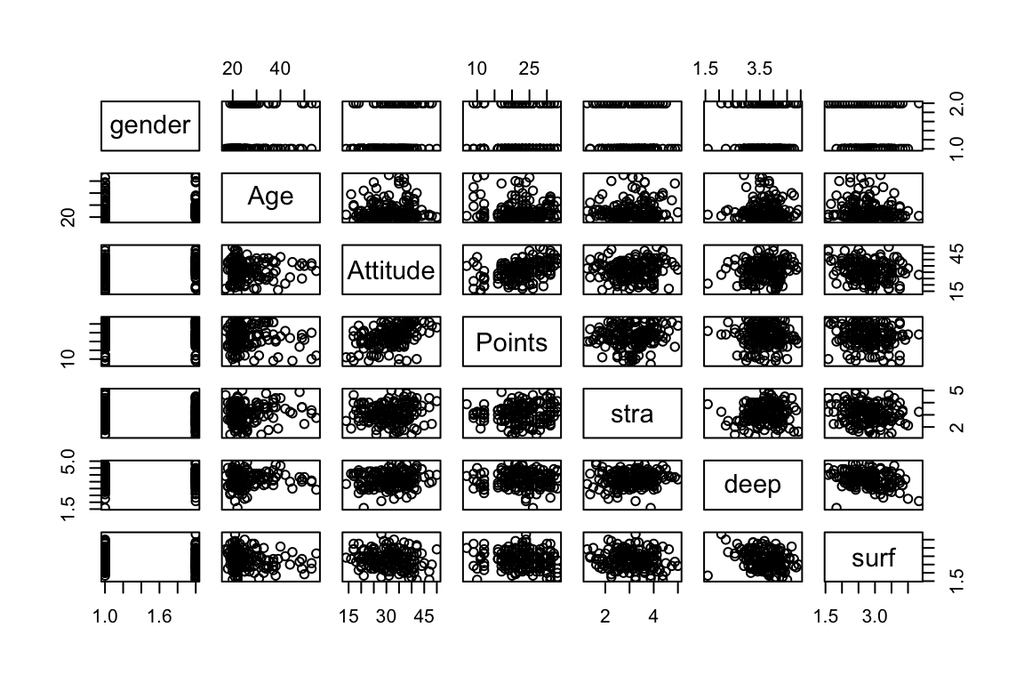

```r
plot(analysis_dataset)
```

# By having a look at the correlation analysis we can identify the factors with the highest correspondance. Those will be further explained below.

##Attitude vs Points

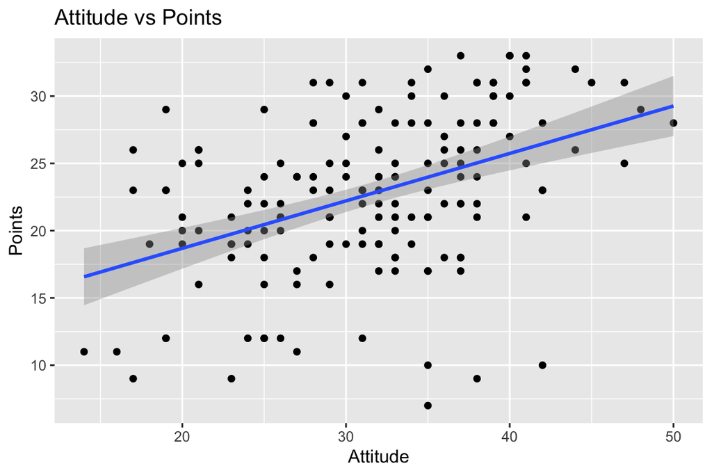

```r
p1 <- ggplot(data.frame(analysis_dataset), aes(x = Attitude, y = Points))
p2 <- p1 + geom_point()
p3 <- p2 + geom_smooth(method = "lm")
p4 <- p3+ggtitle("Attitude vs Points")
print(p4)
```

```r
model <- lm(analysis_dataset$Points~analysis_dataset$Attitude)
summary(model)
```

```
##
## Call:
## lm(formula = analysis_dataset$Points ~ analysis_dataset$Attitude)
##
## Residuals:
##      Min       1Q   Median       3Q      Max
## -16.9763  -3.2119   0.4339   4.1534  10.6645
##
## Coefficients:
##                           Estimate Std. Error t value Pr(>|t|)
## (Intercept)               11.63715    1.83035   6.358 1.95e-09 ***
## analysis_dataset$Attitude  0.35255    0.05674   6.214 4.12e-09 ***
## ---
## Signif. codes:  0 '***' 0.001 '**' 0.01 '*' 0.05 '.' 0.1 ' ' 1
##
## Residual standard error: 5.32 on 164 degrees of freedom
## Multiple R-squared:  0.1906, Adjusted R-squared:  0.1856
## F-statistic: 38.61 on 1 and 164 DF,  p-value: 4.119e-09
```

#p-value being lowest in this correlation graph.

# Other way of doing the same thing

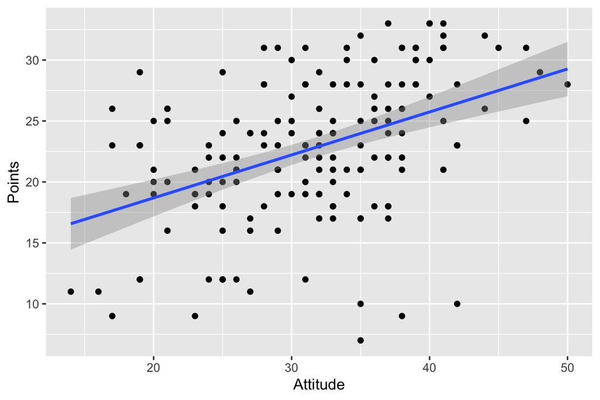

```r
library(ggplot2)
qplot(Attitude, Points, data = analysis_dataset) + geom_smooth(method = "lm")
```

```r
my_model <- lm(Points ~ Attitude, data = analysis_dataset)
```

##surf vs deep

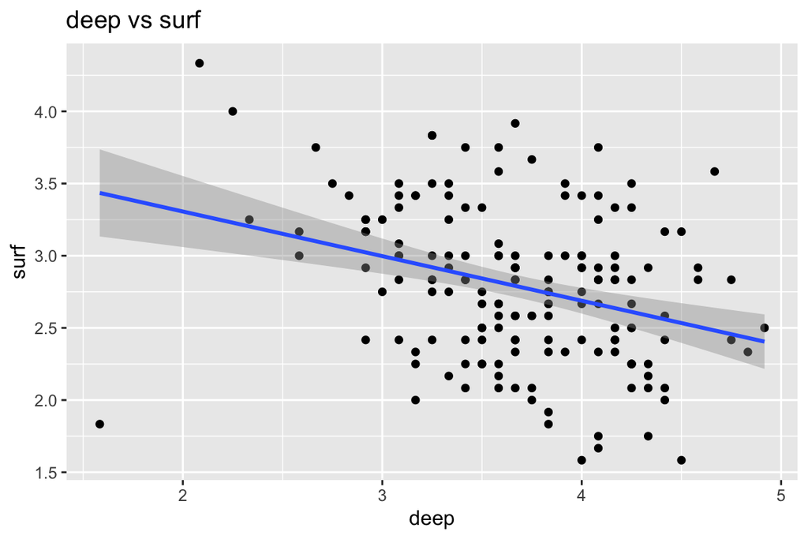

```r
p1 <- ggplot(data.frame(analysis_dataset), aes(x = deep, y = surf))
p2 <- p1 + geom_point()
p3 <- p2 + geom_smooth(method = "lm")
p4 <- p3+ggtitle("deep vs surf")
print(p4)
```

```r
model <- lm(analysis_dataset$surf~analysis_dataset$deep)
summary(model)
```

```
##
## Call:
## lm(formula = analysis_dataset$surf ~ analysis_dataset$deep)
##
## Residuals:
##      Min       1Q   Median       3Q      Max
## -1.60164 -0.34081  0.01032  0.30539  1.12548
##
## Coefficients:
##                       Estimate Std. Error t value Pr(>|t|)
## (Intercept)            3.92426    0.26235  14.958  < 2e-16 ***
## analysis_dataset$deep -0.30902    0.07051  -4.383 2.08e-05 ***
## ---
## Signif. codes:  0 '***' 0.001 '**' 0.01 '*' 0.05 '.' 0.1 ' ' 1
##
## Residual standard error: 0.5019 on 164 degrees of freedom
## Multiple R-squared:  0.1048, Adjusted R-squared:  0.09939
## F-statistic: 19.21 on 1 and 164 DF,  p-value: 2.085e-05
```

# p-value being second lowest in this comparison

##Attitude vs surf

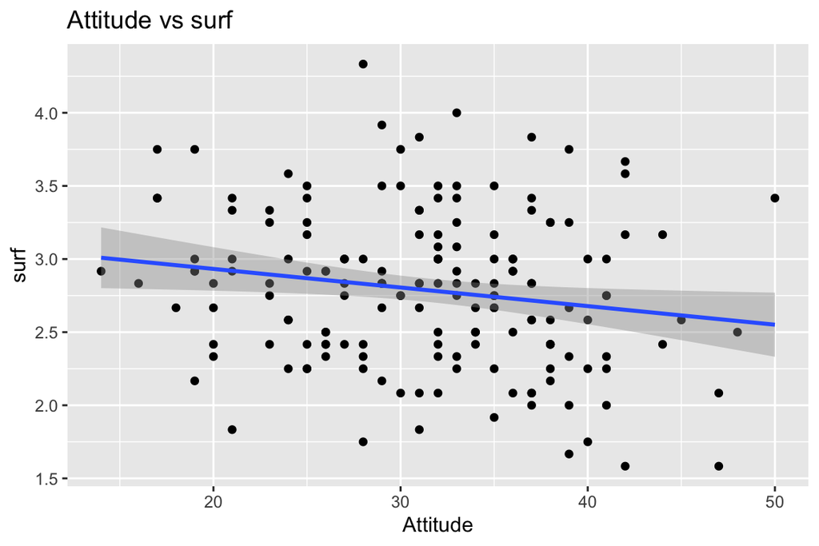

```r
p1 <- ggplot(data.frame(analysis_dataset), aes(x = Attitude, y = surf))
p2 <- p1 + geom_point()
p3 <- p2 + geom_smooth(method = "lm")
p4 <- p3+ggtitle("Attitude vs surf")
print(p4)
```

```r
model <- lm(analysis_dataset$surf~analysis_dataset$Attitude)
summary(model)
```

```
##
## Call:
## lm(formula = analysis_dataset$surf ~ analysis_dataset$Attitude)
##
## Residuals:
##      Min       1Q   Median       3Q      Max
## -1.08644 -0.40136 -0.01364  0.35040  1.50259
##
## Coefficients:
##                           Estimate Std. Error t value Pr(>|t|)
## (Intercept)                3.18686    0.17968  17.737   <2e-16 ***
## analysis_dataset$Attitude -0.01272    0.00557  -2.283   0.0237 *
## ---
## Signif. codes:  0 '***' 0.001 '**' 0.01 '*' 0.05 '.' 0.1 ' ' 1
##
## Residual standard error: 0.5222 on 164 degrees of freedom
## Multiple R-squared:  0.03082,    Adjusted R-squared:  0.02491
## F-statistic: 5.214 on 1 and 164 DF,  p-value: 0.02368
```

#p-value being third lowest in this comparison. The abovementioned three statistical models (Attitude vs surf, surf vs deep, Attitude vs Points) show a rather significant coefficient. In the linear model especially Attitude (predictor variable) vs Points (response variable) have a statistically strong correlation.

#Creating a multiple variable model

```r
library(GGally)
```

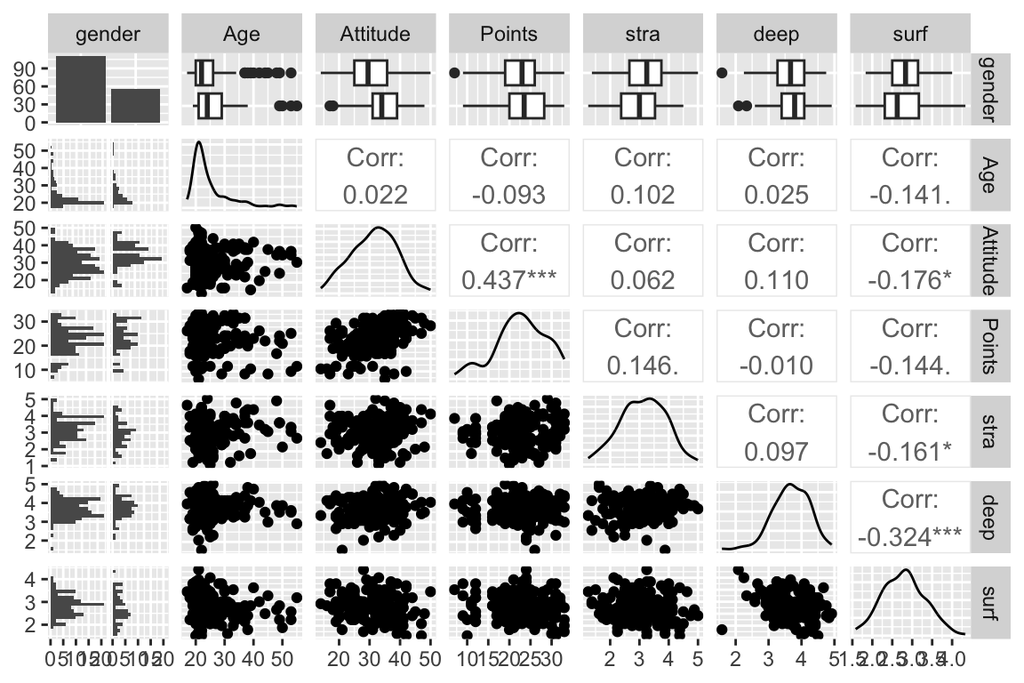

```r
library(ggplot2)
ggpairs(analysis_dataset, lower = list(combo = wrap("facethist", bins = 20)))
```

```r
my_model2 <- lm(Points ~ Attitude + stra, data = analysis_dataset)
summary(my_model2)
```

```
##
## Call:
## lm(formula = Points ~ Attitude + stra, data = analysis_dataset)
##
## Residuals:
##      Min       1Q   Median       3Q      Max
## -17.6436  -3.3113   0.5575   3.7928  10.9295
##
## Coefficients:
##             Estimate Std. Error t value Pr(>|t|)
## (Intercept)  8.97290    2.39591   3.745  0.00025 ***
## Attitude     0.34658    0.05652   6.132 6.31e-09 ***
## stra         0.91365    0.53447   1.709  0.08927 .
## ---
## Signif. codes:  0 '***' 0.001 '**' 0.01 '*' 0.05 '.' 0.1 ' ' 1
##
## Residual standard error: 5.289 on 163 degrees of freedom
## Multiple R-squared:  0.2048, Adjusted R-squared:  0.1951
## F-statistic: 20.99 on 2 and 163 DF,  p-value: 7.734e-09
```

```r
my_model2 <- lm(Points ~ Attitude + stra, data = analysis_dataset)
```

# Linear model with multiple variables

```r
lm(my_model2)
```

```
##
## Call:
## lm(formula = my_model2)
##
## Coefficients:
## (Intercept)     Attitude         stra
##      8.9729       0.3466       0.9137
```

```r
par(mfrow = c(2, 2))
```

# Residuals vs Fitted values (which = 1)

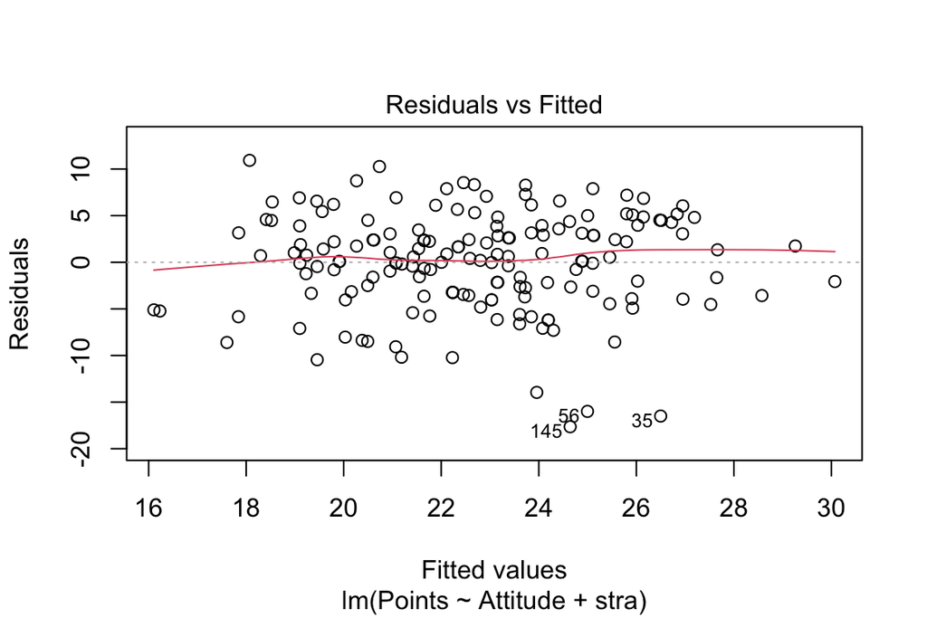

```r
plot(my_model2, which = 1)
```

# Normal QQ-plot (which = 2)

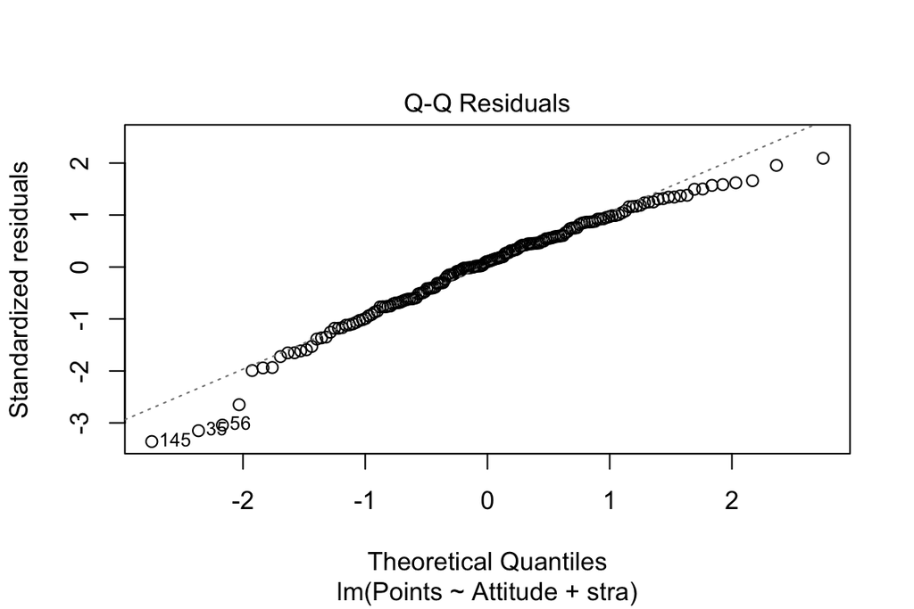

```r
plot(my_model2, which = 2)
```

# Residuals vs Leverage (which = 5)

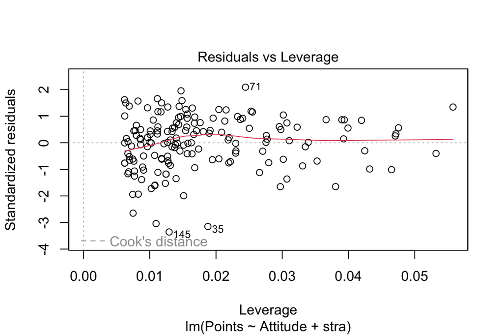

```r
plot(my_model2, which = 5)
```

#Multiple explanatory variables all in one

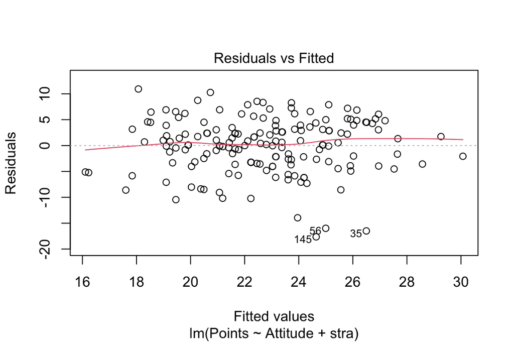

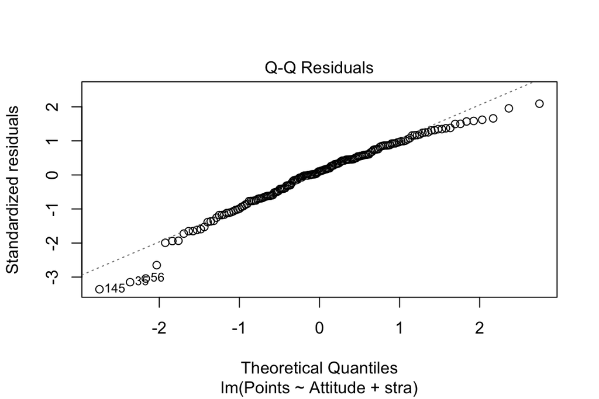

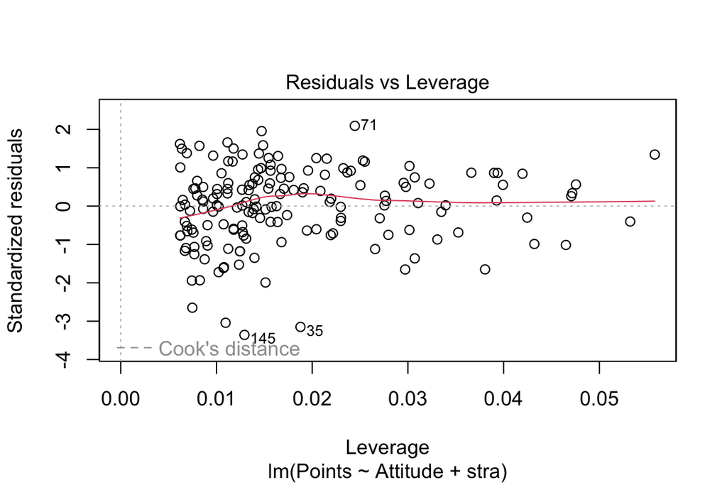

```r
plot(my_model2, which = c(1, 2, 5))
```

#Making predictions

```r
m <- lm(Points ~ Attitude, data = analysis_dataset)
summary(m)
```

```
##
## Call:
## lm(formula = Points ~ Attitude, data = analysis_dataset)
##
## Residuals:
##      Min       1Q   Median       3Q      Max
## -16.9763  -3.2119   0.4339   4.1534  10.6645
##
## Coefficients:
##             Estimate Std. Error t value Pr(>|t|)
## (Intercept) 11.63715    1.83035   6.358 1.95e-09 ***
## Attitude     0.35255    0.05674   6.214 4.12e-09 ***
## ---
## Signif. codes:  0 '***' 0.001 '**' 0.01 '*' 0.05 '.' 0.1 ' ' 1
##
## Residual standard error: 5.32 on 164 degrees of freedom
## Multiple R-squared:  0.1906, Adjusted R-squared:  0.1856
## F-statistic: 38.61 on 1 and 164 DF,  p-value: 4.119e-09
```

As we can se above the Adjusted R-squared is 0.1856. This is not a sign of a good model.

#New observations

```r
new_attitudes <- c("Mia" = 3.8, "Mike"= 4.4, "Riikka" = 2.2, "Pekka" = 2.9)
new_data <- data.frame(Attitude = new_attitudes)
print(new_data)
```

```
##        Attitude
## Mia         3.8
## Mike        4.4
## Riikka      2.2
## Pekka       2.9
```

##Predicting exam points based on the model created above.

```r
predictions <- predict(m, newdata = new_data)
print(predictions)
```

```
##      Mia     Mike   Riikka    Pekka
## 12.97683 13.18836 12.41275 12.65954
```

Here we go again…

# Assignment 3

Konrad Sopyllo

The data presented below concers student performance in Portugese high school education. It focuses mainly onperformance in two distinct subjects: Mathematics (mat) and Portuguese language (por). The data was collected by Cortez and Silva in 2008.

```r
url <- "https://raw.githubusercontent.com/KimmoVehkalahti/Helsinki-Open-Data-Science/master/datasets/alc.csv"
alc_data <- read.csv(url)

variable_names <- names(alc_data)
cat("Variable Names:", paste(variable_names, collapse = ", "), "\n\n")
```

```
## Variable Names: school, sex, age, address, famsize, Pstatus, Medu, Fedu, Mjob, Fjob, reason, guardian, traveltime, studytime, schoolsup, famsup, activities, nursery, higher, internet, romantic, famrel, freetime, goout, Dalc, Walc, health, failures, paid, absences, G1, G2, G3, alc_use, high_use
```

In this section we will choose four random factors and analyse their correlation with alcohol consumption. First we will make a hypothesis on the result and then calculate it. In addition we will interpret coefficients of the models and their odds ratios

#Hypothesis 1. Romantic relationship is correlated with higher alcohol use.

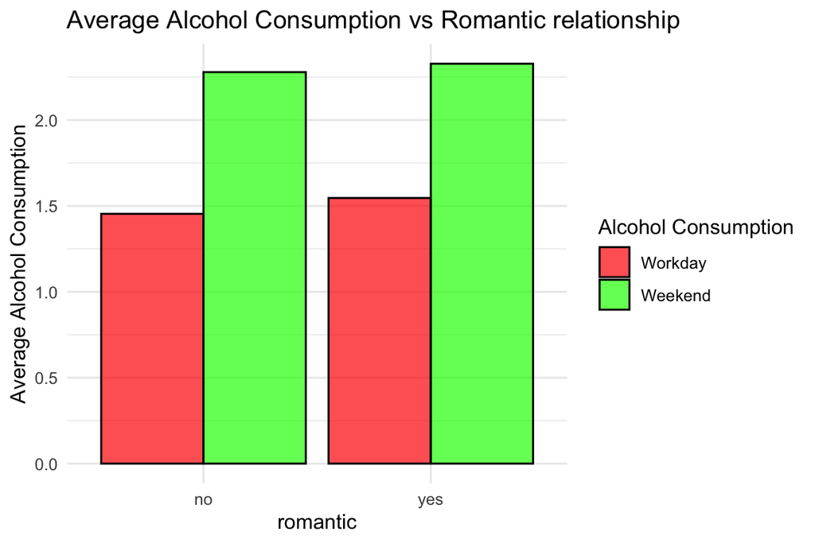

```r
library(tidyverse)
gathered_data <- alc_data %>%
  gather(key = "variable", value = "alcohol_consumption", Dalc, Walc)

ggplot(gathered_data, aes(x = romantic, fill = variable, y = alcohol_consumption)) +
  geom_bar(position = "dodge", stat = "summary", fun = "mean", color = "black", alpha = 0.7) +
  labs(title = "Average Alcohol Consumption vs Romantic relationship",
       x = "romantic",
       y = "Average Alcohol Consumption") +
  scale_fill_manual(values = c("red", "green"), name = "Alcohol Consumption",
                    labels = c("Workday", "Weekend")) +
  theme_minimal()
```

```r
logistic_model <- glm(high_use ~ Dalc + Walc + romantic,
                      data = alc_data,
                      family = binomial,
                      maxit = 1000)
summary(logistic_model)
```

```
##
## Call:
## glm(formula = high_use ~ Dalc + Walc + romantic, family = binomial,
##     data = alc_data, maxit = 1000)
##
## Coefficients:
##               Estimate Std. Error z value Pr(>|z|)
## (Intercept) -2.432e+02  4.161e+05  -0.001        1
## Dalc         5.423e+01  1.122e+05   0.000        1
## Walc         5.397e+01  9.790e+04   0.001        1
## romanticyes -2.844e-01  9.737e+04   0.000        1
##
## (Dispersion parameter for binomial family taken to be 1)
##
##     Null deviance: 4.5204e+02  on 369  degrees of freedom
## Residual deviance: 3.4622e-10  on 366  degrees of freedom
## AIC: 8
##
## Number of Fisher Scoring iterations: 29
```

```r
odds_ratios <- exp(coef(logistic_model))
conf_intervals <- exp(confint(logistic_model))
```

[output not shown]

```r
cat("\nOdds Ratios and 95% Confidence Intervals:\n")
```

```
##
## Odds Ratios and 95% Confidence Intervals:
```

```r
data.frame(Odds_Ratio = odds_ratios,
           Lower_CI = conf_intervals[, 1],
           Upper_CI = conf_intervals[, 2])
```

```
##                Odds_Ratio Lower_CI Upper_CI
## (Intercept) 2.333493e-106        0        0
## Dalc         3.569417e+23        0      Inf
## Walc         2.755430e+23        0      Inf
## romanticyes  7.524331e-01        0       NA
```